# Notebook 04: Preprocessing Pipeline

## Objectives

In this notebook we develop and validate the preprocessing pipeline for the PANORAMA pancreatic CT dataset.

The goals are:

- Load CT volumes using the reusable src package
- Inspect CT intensity distributions
- Perform Hounsfield Unit (HU) clipping
- Normalize CT intensities
- Resample all scans to a common voxel spacing
- Prepare processed volumes for model training

Unlike the previous notebooks, this notebook focuses on image preprocessing rather than dataset exploration.

```python
# ============================================================
# Imports
# ============================================================

from pathlib import Path
import sys

import numpy as np
import matplotlib.pyplot as plt

from importlib import reload
```

```python
# ============================================================
# Configure project path
# ============================================================

PROJECT_ROOT = Path.cwd().parent

if str(PROJECT_ROOT) not in sys.path:
    sys.path.insert(0, str(PROJECT_ROOT))

print("Project root:")
print(PROJECT_ROOT)
```

```
Project root:
d:\Pancreatic_Cancer_Thesis
```

```python
# ============================================================
# Import project modules
# ============================================================

import src.io
import src.visualization
import src.preprocessing

reload(src.io)
reload(src.visualization)
reload(src.preprocessing)

from src.io import *
from src.visualization import *
from src.preprocessing import *

print("Modules loaded successfully!")
```

```
Modules loaded successfully!
```

```python
# ============================================================
# Dataset summary
# ============================================================

print_dataset_summary()
```

```
========================================
PANORAMA Dataset
========================================
CT volumes          : 557
Manual labels       : 482
Automatic labels    : 1756
Metadata rows       : 2238
========================================
```

```python
# ============================================================
# Select one CT case
# ============================================================

study_id = list_ct_cases()[0]

print("Study ID:", study_id)
```

```
Study ID: 100000_00001
```

```python
# ============================================================
# Load case
# ============================================================

case = load_case(study_id)

print_case_info(case)
```

```
========================================
100000_00001
========================================
Mask: Automatic
Shape: (90, 512, 512)
Spacing: (0.6949999928474426, 0.6949999928474426, 2.3999998569488525)
Origin: (-181.6833038330078, -177.777099609375, 1759.4000244140625)
```

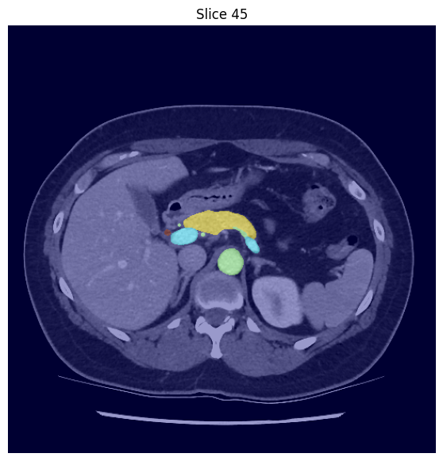

```python
# ============================================================
# Visualize CT
# ============================================================

show_case(case)
```

# Section 2: Inspect CT Intensity Distribution

CT images are stored in Hounsfield Units (HU), where each voxel represents the X-ray attenuation of tissue.

Typical HU values include:

| Tissue | Approximate HU |
| --- | --- |
| Air | -1000 |
| Lung | -700 |
| Fat | -100 |
| Water | 0 |
| Soft tissue | 30–80 |
| Bone | 300–3000 |

Before applying any preprocessing, we first inspect the intensity distribution of one CT scan. This helps us understand the dynamic range of the data and motivates later steps such as HU clipping and normalization.

```python
# ============================================================
# Extract CT volume
# ============================================================

image = case["ct_array"]

print("Array shape :", image.shape)
print("Data type   :", image.dtype)
```

```
Array shape : (90, 512, 512)
Data type   : int16
```

```python
# ============================================================
# CT intensity statistics
# ============================================================

print(f"Minimum HU : {image.min():.1f}")
print(f"Maximum HU : {image.max():.1f}")

print(f"Mean HU    : {image.mean():.2f}")
print(f"Median HU  : {np.median(image):.2f}")

print(f"Std HU     : {image.std():.2f}")
```

```
Minimum HU : -2048.0
Maximum HU : 1558.0
Mean HU    : -701.45
Median HU  : -133.00
Std HU     : 824.27
```

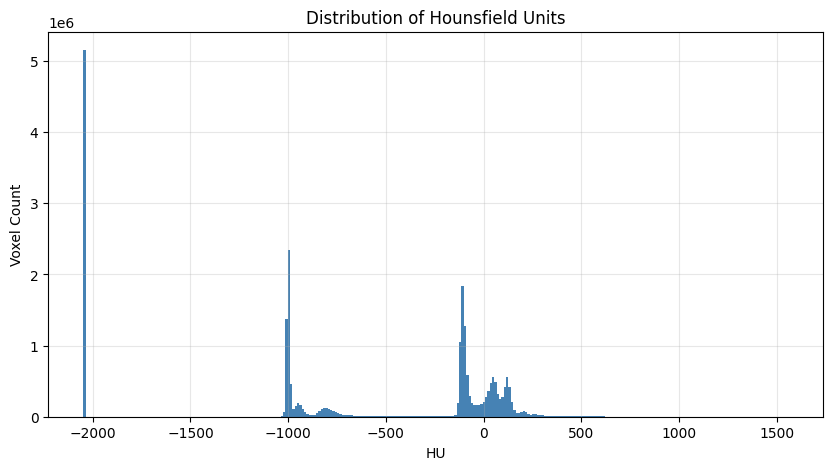

```python
# ============================================================
# Histogram of Hounsfield Units
# ============================================================

plt.figure(figsize=(10,5))

plt.hist(
    image.ravel(),
    bins=300,
    color="steelblue"
)

plt.title("Distribution of Hounsfield Units")

plt.xlabel("HU")

plt.ylabel("Voxel Count")

plt.grid(alpha=0.3)

plt.show()
```

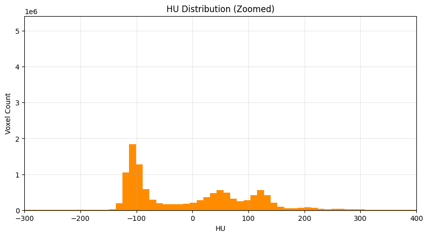

```python
# ============================================================
# Zoom into clinically relevant HU range
# ============================================================

plt.figure(figsize=(10,5))

plt.hist(
    image.ravel(),
    bins=300,
    color="darkorange"
)

plt.xlim(-300, 400)

plt.title("HU Distribution (Zoomed)")

plt.xlabel("HU")

plt.ylabel("Voxel Count")

plt.grid(alpha=0.3)

plt.show()
```

```python
# ============================================================
# Intensity percentiles
# ============================================================

percentiles = [0, 1, 5, 25, 50, 75, 95, 99, 100]

for p in percentiles:
    value = np.percentile(image, p)
    print(f"{p:>3}% : {value:8.2f}")
```

```
  0% : -2048.00
  1% : -2048.00
  5% : -2048.00
 25% : -1006.00
 50% :  -133.00
 75% :   -16.00
 95% :   137.00
 99% :   342.00
100% :  1558.00
```

## Observations

Because neural networks do not benefit from these extreme intensities, the next preprocessing step will clip the CT volume to a fixed HU window before normalization.

# Section 3: Hounsfield Unit Clipping

CT images contain a wide range of intensity values. However, pancreatic tissue occupies only a small portion of this range.

Very low values (air and background) and very high values (bone and metallic objects) contribute little useful information for pancreatic cancer detection and may negatively affect neural network training.

Therefore, CT intensities are clipped to a soft-tissue window before normalization.

For this project we use:

- Lower bound: **-150 HU**
- Upper bound: **250 HU**

These values preserve pancreatic anatomy while suppressing irrelevant intensity extremes.

```python
# ============================================================
# Apply HU clipping
# ============================================================

clipped = clip_hu(image)

print("Original range")
print(image.min(), image.max())

print()

print("Clipped range")
print(clipped.min(), clipped.max())
```

```
Original range
-2048 1558

Clipped range
-150 250
```

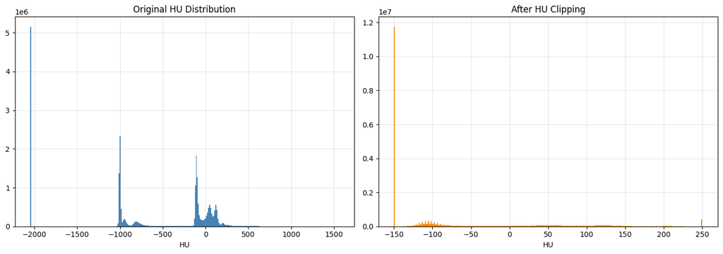

```python
# ============================================================
# Histogram comparison
# ============================================================

fig, ax = plt.subplots(
    1,
    2,
    figsize=(14,5)
)

ax[0].hist(
    image.ravel(),
    bins=300,
    color="steelblue"
)

ax[0].set_title("Original HU Distribution")

ax[0].set_xlabel("HU")

ax[0].grid(alpha=.3)

ax[1].hist(
    clipped.ravel(),
    bins=300,
    color="darkorange"
)

ax[1].set_title("After HU Clipping")

ax[1].set_xlabel("HU")

ax[1].grid(alpha=.3)

plt.tight_layout()

plt.show()
```

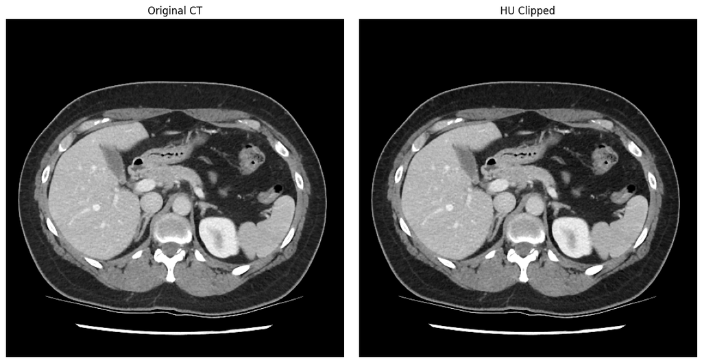

```python
# ============================================================
# Compare CT slices
# ============================================================

slice_idx = image.shape[0] // 2

fig, ax = plt.subplots(
    1,
    2,
    figsize=(12,6)
)

ax[0].imshow(
    window_image(image[slice_idx]),
    cmap="gray"
)

ax[0].set_title("Original CT")

ax[0].axis("off")

ax[1].imshow(
    window_image(clipped[slice_idx]),
    cmap="gray"
)

ax[1].set_title("HU Clipped")

ax[1].axis("off")

plt.tight_layout()

plt.show()
```

```python
# ============================================================
# Difference image
# ============================================================

difference = image - clipped

print("Changed voxels:",
      np.count_nonzero(difference))

print("Percentage changed:",
      100*np.count_nonzero(difference)/difference.size)
```

```
Changed voxels: 12148261
Percentage changed: 51.49104224310981
```

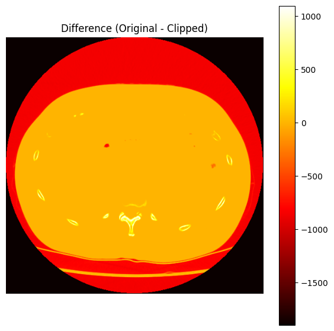

```python
plt.figure(figsize=(7,7))

plt.imshow(
    difference[slice_idx],
    cmap="hot"
)

plt.title("Difference (Original - Clipped)")

plt.colorbar()

plt.axis("off")

plt.show()
```

```python
lower = -150
upper = 250

below = np.sum(image < lower)

above = np.sum(image > upper)

total = image.size

print(f"Below {lower} HU : {below:,}")

print(f"Above {upper} HU : {above:,}")

print(f"Total voxels     : {total:,}")

print()

print(f"Below (%) : {100*below/total:.2f}%")

print(f"Above (%) : {100*above/total:.2f}%")
```

```
Below -150 HU : 11,746,389
Above 250 HU : 401,872
Total voxels     : 23,592,960

Below (%) : 49.79%
Above (%) : 1.70%
```

## Observations

HU clipping removes extreme intensity values while preserving the majority of soft tissue.

Most of the modified voxels correspond to background air and dense bone.

This operation reduces the dynamic range of CT intensities and prepares the images for normalization, improving numerical stability during deep learning model training.